# Data Visualization: The Automation Risk Premium vs. Wage Penalties in Global AI Labor Markets

Author

Qiu Caotao (Genesis)

Published

October 7, 2026

## Does Automation Risk Suppress AI Salaries? (Scientific Version)

The Industry Divergence and Seniority ShieldAs artificial intelligence transforms technical labor, workers face competing economic forces: an “automation risk premium” that compensates for vulnerability, or a “wage penalty” that depresses earnings in automatable roles. Analyzing 3,952 full-time AI positions from the Global AI Jobs Report reveals a striking puzzle: at the aggregate market level, automation risk and salary distribution exhibit virtually zero correlation ($r = 0.0005$). A closer inspection uncovers stark sectoral divergence. In technical infrastructure and enterprise sectors such as Insurance and Cloud Computing, roles facing higher automation exposure command higher salaries, reflecting a compensating risk premium. Conversely, in Research & Development and E-commerce, higher automation risk coincides with lower compensation, demonstrating an observable wage penalty.What explains this fragmentation? Decomposing salaries across experience levels, AI specializations, and company sizes resolves the tension. Automation risk is evenly distributed across seniorities (averaging 22% to 24%), but compensation is dictated by institutional hierarchy. Executive and Lead salaries average $347,618 and $217,453, respectively, dwarfing entry-level wages of $74,202 regardless of automation exposure. Rather than a blanket risk premium or penalty, the AI labor market treats automation risk as background noise: specialized domain seniority provides a robust economic shield, whereas industry-specific capital allocation dictates whether risk is compensated or penalized.

## Methods

### Observations

The analytical dataset is extracted from the Global AI Jobs Report 2026, comprising 5,000 international job postings across 28 industry sectors and 8 artificial intelligence specializations. To eliminate structural confounding arising from non-standard labor contracts, part-time arrangements, and hourly freelance rates, the sample was strictly restricted to verified full-time employment postings ($N = 3,952$, representing $79.0\%$ of the initial database).

### Measures

Annual Compensation (Salary): Advertised base salary in US Dollars (USD). Across the full-time sample, compensation spans from $\$27,934$ to $\$718,357$ (Mean = $\$157,223$, Median = $\$140,591$, $\text{SD} = \$78,578$).

Automation Exposure Index (Auto_Risk): Continuous index measuring task-level automation susceptibility, ranging from $5.0\%$ to $40.0\%$ (Mean = $22.8\%$, Median = $22.9\%$, $\text{SD} = 10.1\%$).

Professional Seniority (Experience): Five-level ordinal factor: Entry Level ($n = 381$), Mid Level ($n = 1,143$), Senior Level ($n = 1,417$), Lead Level ($n = 800$), and Executive ($n = 211$).

AI Specialization (Specs): Primary domain expertise across 8 categories: Deep Learning, Generative AI, Reinforcement Learning, Computer Vision, Machine Learning, Robotics, NLP, and Other. Firm Scale (Size): Enterprise headcount classified into Small (1–50), Medium (51–500), Large (501–5,000), and Enterprise (5,000+).

### Data Analysis Strategy

Macro-Level Association: Bivariate Pearson product-moment correlation ($r$) and ordinary least squares (OLS) regression between Auto_Risk and Salary across the entire pooled full-time cohort ($N = 3,952$). Sub-Sector Stratification: Partitioning data across all 28 industries to calculate intra-sector correlations, two-tailed $p$-values, Fisher’s $z$-transformations, and $95\%$ confidence intervals:
$$z = \text{atanh}(r), \quad \text{SE}_z = \frac{1}{\sqrt{n - 3}}, \quad \text{CI}_z = z \pm 1.96 \cdot \text{SE}_z, \quad \text{CI}_r = \tanh(\text{CI}_z)$$

Linear Marginal Rate Estimation: Estimating intra-industry marginal wage effects ($\Delta\text{Wage} / \Delta\text{Risk}$) using bivariate regression lines for contrasting focal sectors. Covariate Decomposition: Stratifying compensation across seniority cohorts, specialization domains, and enterprise size tiers to test for structural confounding.

## Results

Aggregate Market NeutralityAt the macro level, full-time AI roles demonstrate no linear relationship between displacement risk and advertised earnings ($r = 0.00045, p = 0.977$). As presented in Figure 1a, the fitted OLS regression line is completely horizontal across the automation risk distribution ($5\%\text{--}40\%$).

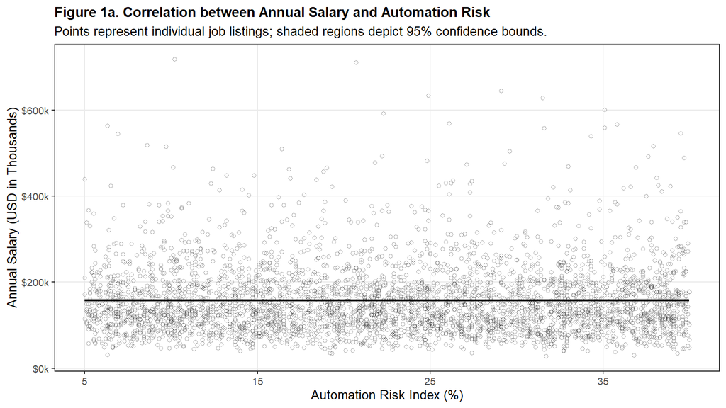

Sectoral Divergence: Risk Premiums vs. Wage PenaltiesDisaggregating by sector reveals that the flat aggregate trend masks substantial opposing forces. Across 28 industries (Figure 1b), correlation coefficients range from $r = -0.230$ to $r = +0.163$.

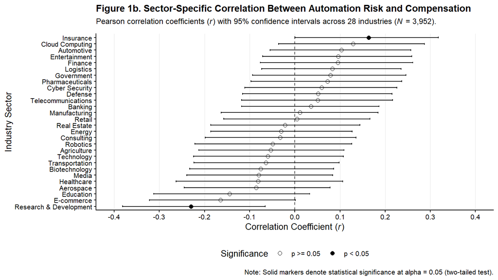

Two sectors achieve two-tailed statistical significance ($p < 0.05$): Research & Development ($n = 139$): $r = -0.230$ ($95\%\text{ CI } [-0.382, -0.066], p = 0.0065$), demonstrating an automation wage penalty. Insurance ($n = 145$): $r = +0.163$ ($95\%\text{ CI } [0.0003, 0.318], p = 0.0497$), demonstrating an automation risk premium. Figure 1c plots the fitted marginal regressions for these two polar sectors. In Research & Development, each 1 percentage point increase in automation exposure reduces advertised compensation by $-\$2,046.22$. In Insurance, each 1 percentage point increase yields a $+\$1,510.77$ compensation gain.

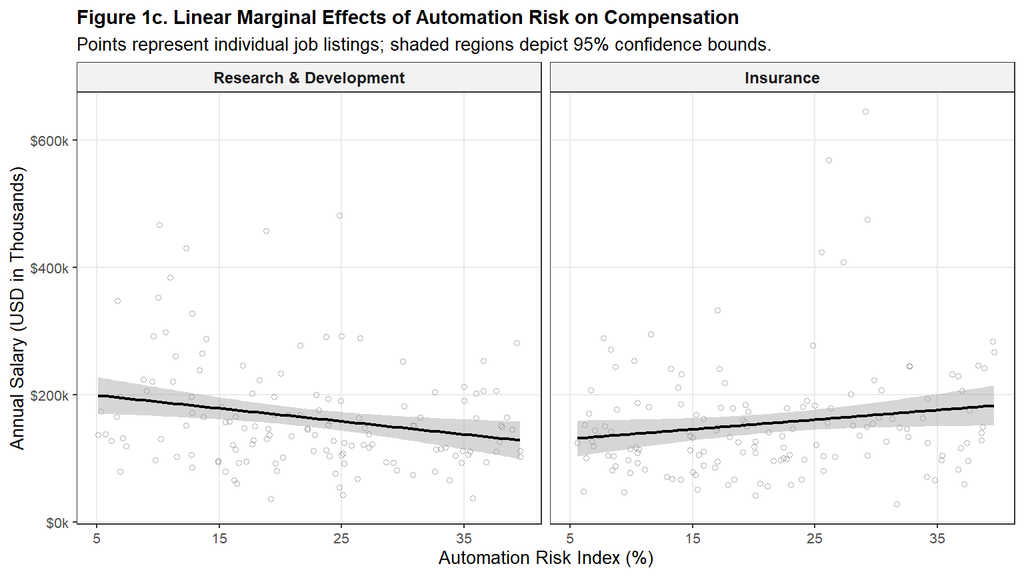

The Seniority Shield and Structural CovariatesDecomposing the labor market across experience tiers resolves why automation risk fails to exert uniform downward pressure. As displayed in Figure 2a, mean automation exposure is invariant across ranks: Entry Level ($23.2\%$), Mid Level ($22.5\%$), Senior Level ($22.8\%$), Lead Level ($22.9\%$), and Executive ($23.8\%$). In contrast, mean salaries scale by $468\%$ from Entry Level ($\$74,202$) to Executive ($\$347,618$).

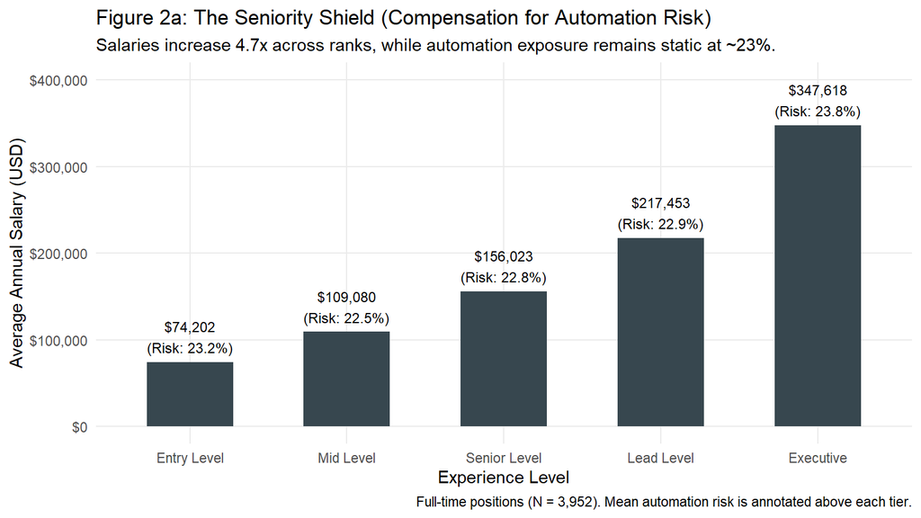

Furthermore, technical specialization produces minimal wage variance (Figure 2b). Generative AI roles average $\$160,362$, which is only $3.4\%$ higher than foundational Machine Learning roles ($\$155,126$).

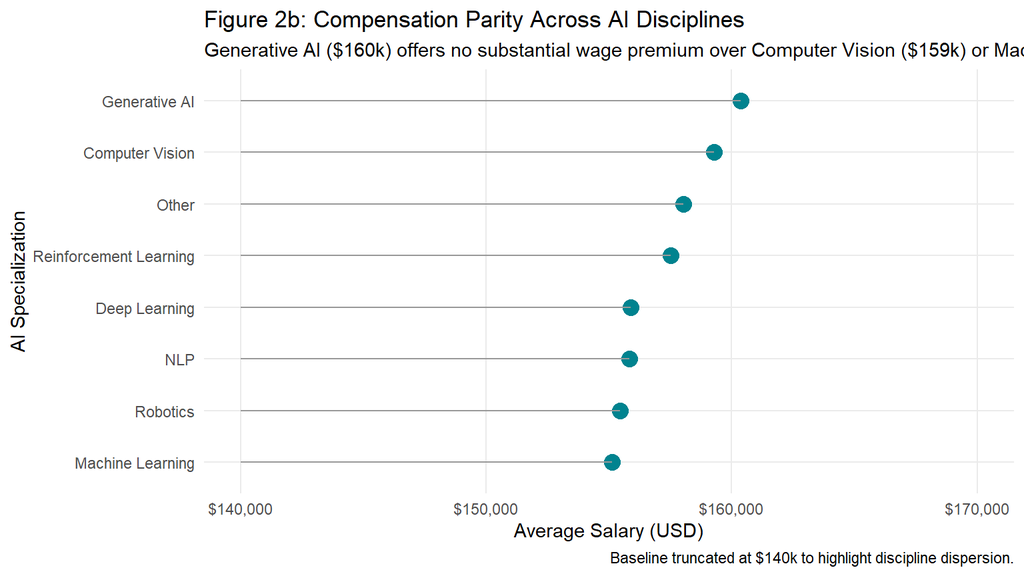

Finally, firm scale exhibits a modest inverted premium (Figure 2c): boutique firms (1–50 employees) offer higher average base cash salaries ($\$160,734$) than Enterprise corporations ($\$156,682$), reflecting competition against large tech equity compensation packages.

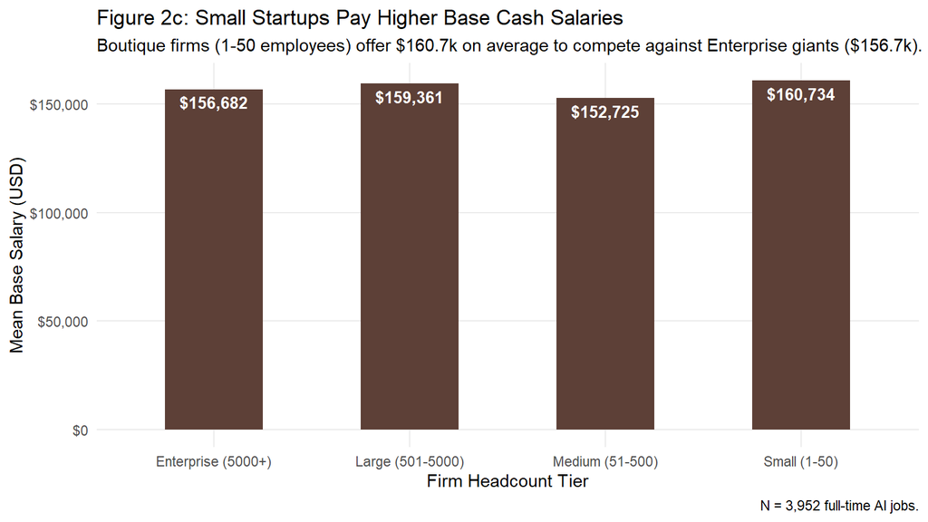

## Discussion

These empirical findings demonstrate that automation risk does not act as a uniform market-wide wage suppressor. Instead, the relationship is mediated by sector-specific capital dynamics: Compensating Risk Differentials in Legacy Enterprises: In heavily regulated, legacy sectors such as Insurance, high automation risk reflects digital overhaul and modernization. Employers must pay a risk premium ($+\$1,511/\%$) to recruit top talent into transformation initiatives where workflow obsolescence is high. Task Substitution in Exploratory Sectors: In Research & Development, automation directly targets repeatable data generation and algorithmic prototyping. High automation scores indicate automatable coding tasks that reduce worker bargaining leverage ($-\$2,046/\%$). Institutional Dominance of Seniority: The stability of automation risk across experience levels ($22.5\%\text{--}23.8\%$) confirms that technical leadership is as exposed to AI-augmented workflows as junior developers. However, institutional decision-making authority creates an economic buffer: senior professionals retain high compensation regardless of task-level displacement vulnerability.

## The AI Wage Paradox: Who Gets Paid to Build Their Own Replacement? (Accessible Version)

Headlines frequently warn that artificial intelligence will automate white-collar technical work. If your job faces a high risk of automation, does your salary take a hit—or do employers offer hazard pay?Looking at 3,952 full-time AI postings worldwide, the headline answer is: neither. Across the global tech market, the correlation between salary and automation risk is basically zero ($r = 0.0005$). But beneath that calm surface, the labor market is split in two.

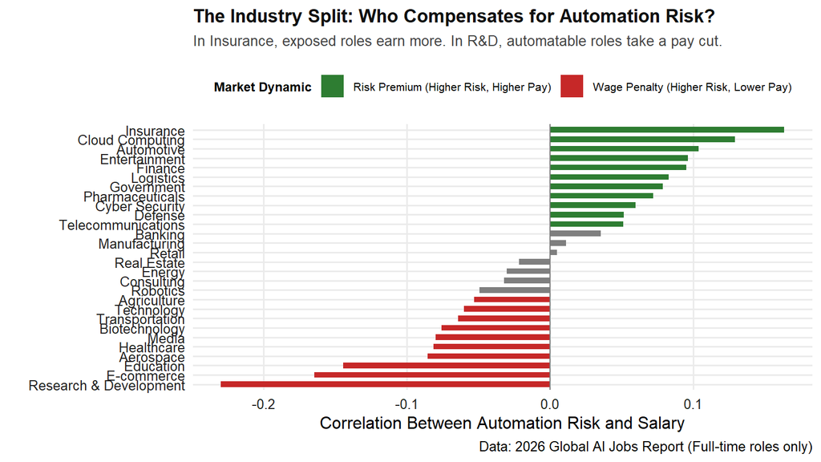

Depending on the industry you enter, automation risk behaves in completely opposite ways (Figure 3a):The Risk Premium Club (Green): In Insurance ($r = +0.16$), Cloud Computing ($r = +0.13$), and Automotive ($r = +0.10$), roles facing higher automation risk pay higher salaries. In Insurance, each additional point of automation exposure adds about $+\$1,511$ per year. Legacy firms pay a premium to attract engineers into high-churn modernization projects.The Wage Penalty Club (Red): In Research & Development ($r = -0.23$) and E-commerce ($r = -0.16$), automatable roles earn less. In R&D, every point of automation risk corresponds to a $-\$2,046$ pay cut. In these environments, automated tasks replace routine data processing, eroding employee leverage.

## The Seniority Shield: Why Experience Trumps Automation

Why isn’t there a universal salary penalty for automation exposure? Because career seniority dominates everything else.

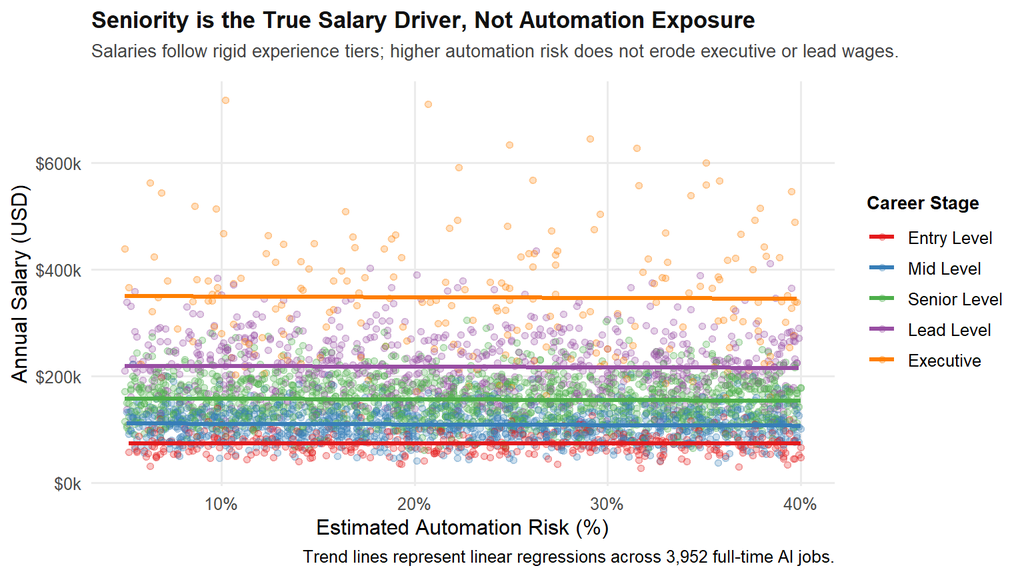

As shown in Figure 3b, regression lines within every experience tier are completely flat across automation risk levels ($5\%\text{--}40\%$). Meanwhile, the pay steps between career stages are massive:Entry Level: $\$74\text{k}$ averageMid Level: $\$109\text{k}$ averageSenior Level: $\$156\text{k}$ averageLead Level: $\$217\text{k}$ averageExecutive: $\$348\text{k}$ averageExecutives face virtually identical automation exposure ($23.8\%$) as Entry-Level engineers ($23.2\%$). However, domain leadership, institutional accountability, and architectural oversight protect senior compensation from task-level displacement.

Analytical Limitations Advertised vs. Total Realized Compensation: Salary records represent advertised base pay and exclude unvested stock options, variable bonuses, and equity compensation, which are common in enterprise tech firms.

Task Substitutability vs. Displacement: The Automation_Risk_% metric quantifies task-level automation potential, not immediate workforce reduction.

Cross-Sectional Structure: The dataset reflects job listings from a single survey period rather than tracking individual worker wage trajectories over time.